# Assignment2_RuijiaLiang

Ruijia Liang u7457322

2022-10-30

[My GitHub Repository](https://github.com/RuijiaLiang/6207Assignment2_RuijiaLiang.git)

# Preparation before analysing

Load the three needed data into R.

Of course the NAs need to be removed.

```r
# remove the NAs in the data
raw_data <- raw_data[complete.cases(raw_data),]
```

Factor type is much more useful than the character type and it is supposed to be done at preparation step.

```r
# useful to have species and treatment column turning into factor type
raw_data$species <- factor(raw_data$species)
raw_data$treatment <- factor(raw_data$treatment)
```

Check problematic entries.

```r
# check spelling in species and treatment by detecting whether there will be a new column caused by error
table(raw_data$species)
```

```
##
##   acantho     ambon   chromis    humbug     lemon whitedams
##       176        43        34       127        49       121
```

```r
table(raw_data$treatment)
```

```
##
##     CO2 control
##     263     287
```

Now the data is all clear! Ready for analysis!

# Generate the summary statistics

Get N and sd and means as we need them later for meta-analysis. I write this function to extract the needed values of each species, which is convient!

```r
# write a function to generate the statistics of each species under different treatment

# define the function name and what should be input
get_statistics <- function(species_name){
  # extract the rows with input species and CO2 treatment
  t_species_data <- raw_data %>% filter(species==species_name,treatment=="CO2")
  # extract the rows with input species and control treatment
  c_species_data <- raw_data %>% filter(species==species_name,treatment=="control")

  # create an empty data frame, ready for storing values of different statistics
  species_statistics <- data.frame(Species = character(), ctrl.n = numeric(), ctrl.mean=numeric(), ctrl.sd = numeric(), oa.n=numeric(), oa.mean = numeric(), oa.sd = numeric())

  # assign the species name
  species_statistics[1,1] <- species_name
  # assign the N of the control group
  species_statistics[1,2] <- length(c_species_data$activity)
  # assign the mean of the control group
  species_statistics[1,3] <- mean(c_species_data$activity)
  # assign the sd of the control group
  species_statistics[1,4] <- sd(c_species_data$activity)
  # assign the N of the CO2 group
  species_statistics[1,5] <- length(t_species_data$activity)
  # assign the N of the CO2 group
  species_statistics[1,6] <- mean(t_species_data$activity)
  # assign the N of the CO2 group
  species_statistics[1,7] <- sd(t_species_data$activity)
  # return the data frame
  return(species_statistics)
}
```

Make that into a well format.

```r
# combine the rows to get a summary data frame
summary_table <- rbind(get_statistics("acantho"),get_statistics("ambon"),get_statistics("chromis"),get_statistics("humbug"),get_statistics("lemon"),get_statistics("whitedams"))
# structure the data frame in a well format
flextable(summary_table) %>% add_header_lines(.,values = "Summary of data")
```

| Summary of data Species | Summary of data ctrl.n | Summary of data ctrl.mean | Summary of data ctrl.sd | Summary of data oa.n | Summary of data oa.mean | Summary of data oa.sd |
| --- | --- | --- | --- | --- | --- | --- |
| acantho | 90 | 28.92639 | 11.246347 | 86 | 27.30042 | 10.415559 |
| ambon | 21 | 17.34102 | 11.451588 | 22 | 18.39429 | 12.200326 |
| chromis | 20 | 26.09986 | 9.125352 | 14 | 24.78010 | 10.975005 |
| humbug | 65 | 34.91652 | 13.867278 | 62 | 40.28306 | 11.915992 |
| lemon | 30 | 19.79766 | 12.256353 | 19 | 26.04157 | 10.957164 |
| whitedams | 61 | 26.58624 | 10.936592 | 60 | 24.45733 | 9.950437 |

# Merge the summary statistics with the clark_paper_data

```r
# combine the paper data with the summary table
sp_data <- cbind(paper_data,summary_table)
# remove the NAs in the data
sp_data <- sp_data[complete.cases(sp_data),]
```

# Merge the sp_data with the meta_data

```r
# combine the data generated above with the big meta data
data <- rbind(sp_data,meta_data)
# remove NA
data <- na.omit(data)
```

# Calculate the log response ratio (lnRR) effect size

Apply the ‘escalc’ function to calculate the lnRR effext size.

```r
# use 'ROM' in measure for the log transformed ratio of means
data <- metafor::escalc(measure = "ROM",
                        # assign the statistic of CO2 and control to vectors
                        m1i=oa.mean, m2i=ctrl.mean, sd1i=oa.sd, sd2i=ctrl.sd, n1i=oa.n, n2i=ctrl.n,
                        # use data as the data source
                        data = data,
                        # define the names
                        var.names = c("lnRR","lnRR_var"))
```

```
## Warning in log(m1i/m2i): NaNs produced
```

```r
# quick check
head(data)
```

```
##
##   Study      Authors Year..online. Year..print.
## 1    a1 Munday et al          2009         2009
## 2    a1 Munday et al          2009         2009
## 3    a1 Munday et al          2009         2009
## 4    a1 Munday et al          2009         2009
## 5    a1 Munday et al          2009         2009
## 6    a1 Munday et al          2009         2009
##                                                                                     Title
## 1 Ocean acidification impairs olfactory discrimination and homing ability of marine fish.
## 2 Ocean acidification impairs olfactory discrimination and homing ability of marine fish.
## 3 Ocean acidification impairs olfactory discrimination and homing ability of marine fish.
## 4 Ocean acidification impairs olfactory discrimination and homing ability of marine fish.
## 5 Ocean acidification impairs olfactory discrimination and homing ability of marine fish.
## 6 Ocean acidification impairs olfactory discrimination and homing ability of marine fish.
```

[output cut: 28 more lines]

The warning message shows there are soma NaNs, which needs to be removed.

```r
data <- data[complete.cases(data),]
```

Now the data is ready to write out.

```r
# use 'write_csv' function to write the tibble to a csv file located in the folder of this working directory
write_csv(data, "u7457322_BIOL3207_Assignment2_data.csv")
```

# Model fitted to the data

Make a extra column to the data in order to add the random effect of observation

```r
# add in observation-level (residual) column
data$residual <- 1:dim(data)[1]
```

Correct meta-analytic model fitted to the data that controls for the sampling variance of lnRR.

```r
# conduct a multilevel meta-analytic model
MLMA <- metafor::rma.mv(yi = lnRR~1, V = lnRR_var, random=list(~1|Study, ~1|residual), method = "REML", test = "t", dfs = "contain", data=data)
MLMA
```

```
##
## Multivariate Meta-Analysis Model (k = 795; method: REML)
##
## Variance Components:
##
##             estim    sqrt  nlvls  fixed    factor
## sigma^2.1  0.4792  0.6922     91     no     Study
## sigma^2.2  4.0497  2.0124    795     no  residual
##
## Test for Heterogeneity:
## Q(df = 794) = 736088678.9542, p-val < .0001
##
## Model Results:
##
## estimate      se    tval  df    pval    ci.lb   ci.ub
##   0.1273  0.1140  1.1162  90  0.2673  -0.0993  0.3539
##
## ---
## Signif. codes:  0 '***' 0.001 '**' 0.01 '*' 0.05 '.' 0.1 ' ' 1
```

# Interpretation

Measure the heterogeneity in effect size estimates across studies.

```r
# calculate I^2 by i2_ml function
i2_result <- orchaRd::i2_ml(MLMA,data = data)

# make a tibble
i2_tibble <- tibble(type = firstup(gsub("I2_", "", names(i2_result))), I2 = i2_result)
# construct a well format
flextable(i2_tibble) %>%
    align(part = "header", align = "center") %>%
    compose(part = "header", j = 1, value = as_paragraph(as_b("Type"))) %>%
    compose(part = "header", j = 2, value = as_paragraph(as_b("I"), as_b(as_sup("2")),
        as_b("(%)")))
```

| Type | I2(%) |
| --- | --- |
| Total | 100.00000 |
| Study | 10.58073 |
| Residual | 89.41927 |

```r
pd_MLMA <- predict(MLMA)
pd_MLMA
```

```
##
##    pred     se   ci.lb  ci.ub   pi.lb  pi.ub
##  0.1273 0.1140 -0.0993 0.3539 -4.1066 4.3612
```

Make a forest plot to visualize the statistic values.

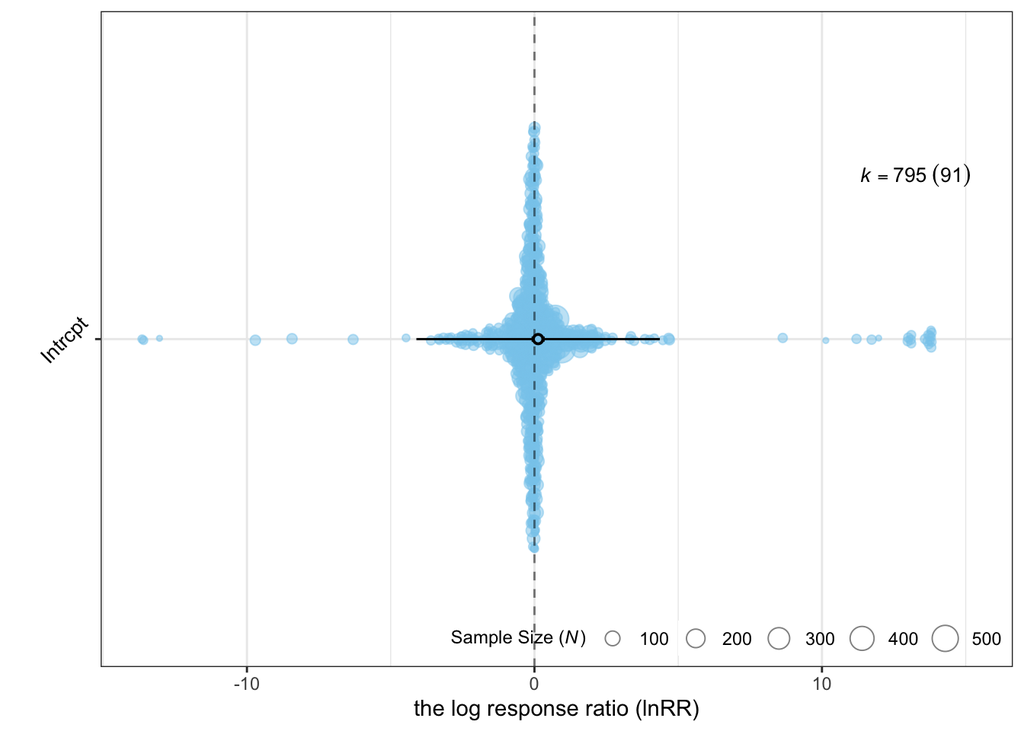

Figure 1: Orchard plot showing the mean lnRR and k is the number of effect sizes and the number of studies are in brackets.

```r
# make the plot using orchard_plot function
# mod = "1" indicates for intercept only model
# N to specify the sample size
forest_1 <- orchaRd::orchard_plot(MLMA, mod = "1", group = "Study", data = data, xlab = "the log response ratio (lnRR)", angle = 45, N = "Average.n")
forest_1
```

Based on the examination and the plot, we can derive the following arguments:

# Funnel plot

Funnel plots are mainly used to observe whether there are various biases in the results of meta-analysis, such as publication bias or other biases. The funnel plot can be used to visually assess whether the study is biased or not.

Here it is made to visually assess the possibility of publication bias.

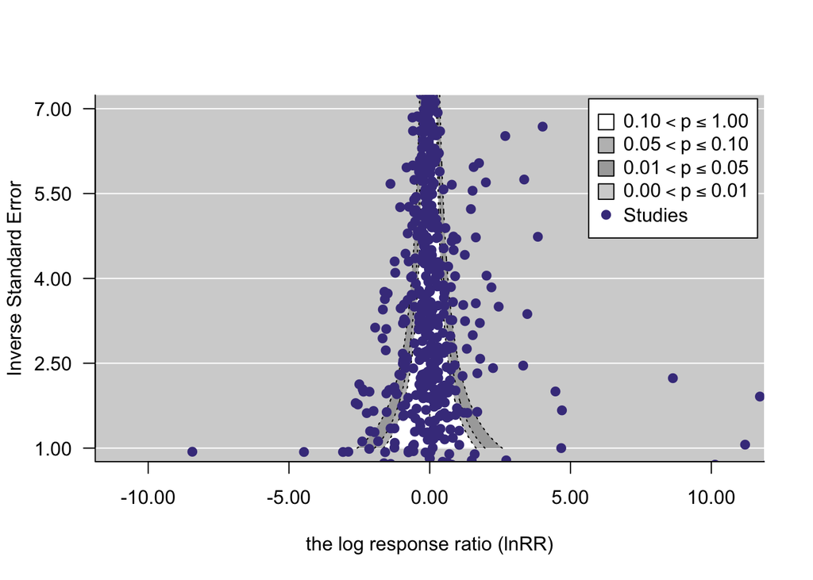

Figure 2: In the funnel plot, the dotted lines are the theoretical 95% sampling variance intervals. Shaded regions represent the p-value of studies.

```r
# make the funnel plot by 'funnel' function
funnel_1 <- metafor::funnel(x = data$lnRR, vi = data$lnRR_var, yaxis = "seinv",
                            # specify the number of decimal places to which the tick mark labels of the x- and y-axis should be rounded.
                            digits = 2,
                            # specify the level of the pseudo confidence interval region
                            level = c(0.1, 0.05, 0.01),
                            # specify the color to use for shading the pseudo confidence interval region and the color to use for the points
                            shade = c("white", "gray", "darkgray"),col = "slateblue4",
                            las = 1,
                            xlab = "the log response ratio (lnRR)",
                            # specify the y-axis limits
                            ylim=c(1:7,by=2),
                            xlim=c(-11,11),
                            # specify the location of the vertical ‘reference’ line
                            refline=0,
                            # add the legend
                            legend = TRUE)
```

Based on Figure 2, we can derive the following arguments:

- More points lie in the positive space, indicating there is a positive correlation between the acidification and the level of fish activity.
- A slightly missing corner occurs at the left bottom, suggesting that there is publication bias, such as when some negative results showing less significant correlation between the acidification and the level of fish activity are not published.

# Time-lag plot

Time-lag plot is to assess how effect sizes may or may not have changed through time.

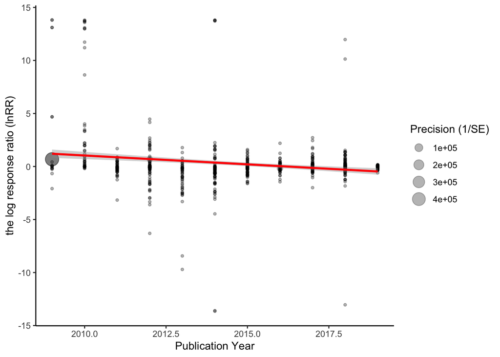

Figure 3: Plot of lnRR as a function of publication year. Points are scaled in relation to their precision (1/sqrt(lnRR_var)). Small points indicate effects with low precision or high sampling varaince

```r
# use online publication year as the data on x axis
timelag_1 <- ggplot(data, aes(y = lnRR, x = Year..online.)) +
  # scale the points in relation to their precision
  geom_point(alpha = 0.3, aes(size = 1/sqrt(lnRR_var))) +
  # add the regression line
  geom_smooth(method = lm, col = "red", show.legend = FALSE) +
  # label the x axis and y axis and the legend
  labs(x = "Publication Year",y = "the log response ratio (lnRR)", size = "Precision (1/SE)") +
  theme_classic()

timelag_1
```

Based on Figure 3, we can derive the following arguments:

- It appears to be a negative and linear relationship with publication year.
- Earlier year studies have slightly higher sampling variance, which means lower precision.
- The earlier year studies show higher effect size compared with studies that are done in later years.

# MLMR with year as a moderator for time-lag bias

We can use multilevel meta-regression to quantify time lag bias.

```r
# centre on the mean of the Year column by simply subtracting every value of Year by the “mean year”
data <- data %>% mutate(Year_c = Year..online. - mean(Year..online.))

# apply rma.mv function to complete multilevel meta-regression
# the moderator here is the online publication year
year_MLMR <- rma.mv(lnRR ~ Year_c, V = lnRR_var, random = list(~1 | Study, ~1 | residual), test = "t", dfs = "contain", data = data)

summary(year_MLMR)
```

```
##
## Multivariate Meta-Analysis Model (k = 795; method: REML)
##
##     logLik    Deviance         AIC         BIC        AICc
## -1782.8090   3565.6180   3573.6180   3592.3213   3573.6688
##
## Variance Components:
##
##             estim    sqrt  nlvls  fixed    factor
## sigma^2.1  0.4017  0.6338     91     no     Study
## sigma^2.2  4.0496  2.0124    795     no  residual
##
## Test for Residual Heterogeneity:
## QE(df = 793) = 128790282.9932, p-val < .0001
##
## Test of Moderators (coefficient 2):
## F(df1 = 1, df2 = 89) = 7.6505, p-val = 0.0069
##
## Model Results:
##
##          estimate      se     tval  df    pval    ci.lb    ci.ub
## intrcpt    0.1456  0.1094   1.3313  89  0.1865  -0.0717   0.3630
## Year_c    -0.1146  0.0414  -2.7660  89  0.0069  -0.1969  -0.0323  **
##
## ---
## Signif. codes:  0 '***' 0.001 '**' 0.01 '*' 0.05 '.' 0.1 ' ' 1
```

We may also wonder how much variation does time when results were published explain in lnRR. And this can be derived from $R^2$ test.

```r
# conduct statistical test to test for heterogeneity using r2_ml function
r2_year_MLMR <- orchaRd::r2_ml(year_MLMR)
r2_year_MLMR
```

```
##    R2_marginal R2_conditional
##     0.02265587     0.11085957
```

Based on the results, we can derive the following arguments:

- Marginal *R<sup>2</sup>* indicates how much variation the ‘fixed effects’ or moderators explain in the model.
- Conditional *R<sup>2</sup>* indicates the full model, that accounts for the both the fixed and random effects, explains 11.0859568% of variance in effect size.
- Time-lag explains 2.2655871% of the effect size variance.
- However, linking to Figure 3 and the statistical examination, the evidence is not so strong to determine the huge effect of time lag, as it only contributes a little part of variance.

# MLMR with inverse sampling variance as a moderator for file-drawer bias

Except for time lag bias, we also got file-drawer effects.

```r
# apply rma.mv function to complete multilevel meta-regression
# the moderator here is the inverse sampling variance, presented as (1 / lnRR_var)
inverse_MLMR <- rma.mv(lnRR ~ (1 / lnRR_var), V = lnRR_var, random = list(~1 | Study, ~1 | residual), test = "t", dfs = "contain", data = data)

summary(inverse_MLMR)
```

```
##
## Multivariate Meta-Analysis Model (k = 795; method: REML)
##
##     logLik    Deviance         AIC         BIC        AICc
## -1788.4810   3576.9621   3582.9621   3596.9933   3582.9925
##
## Variance Components:
##
##             estim    sqrt  nlvls  fixed    factor
## sigma^2.1  0.4792  0.6922     91     no     Study
## sigma^2.2  4.0497  2.0124    795     no  residual
##
## Test for Heterogeneity:
## Q(df = 794) = 736088678.9542, p-val < .0001
##
## Model Results:
##
## estimate      se    tval  df    pval    ci.lb   ci.ub
##   0.1273  0.1140  1.1162  90  0.2673  -0.0993  0.3539
##
## ---
## Signif. codes:  0 '***' 0.001 '**' 0.01 '*' 0.05 '.' 0.1 ' ' 1
```

```r
# conduct statistical test to test for heterogeneity using r2_ml function
r2_inverse_MLMR <- orchaRd::r2_ml(inverse_MLMR)
r2_inverse_MLMR
```

```
##    R2_marginal R2_conditional
##      0.0000000      0.1058073
```

Based on the results, we can derive the following arguments:

- The full model, that accounts for the both the fixed and random effects, explains 10.5807302% of variance in effect size.
- Inverse sampling variance explains 0% of the effect size variance, which is very small.

# MLMR with IF as a moderator for publication bias

IF is likely to be one moderator for potential publication bias.

```r
# apply rma.mv function to complete multilevel meta-regression
# the moderator here is the IF of the publication year
if_MLMR <- rma.mv(lnRR ~ Pub.year.IF, V = lnRR_var, random = list(~1 | Study, ~1 | residual), test = "t", dfs = "contain", data = data)

if_MLMR
```

```
##
## Multivariate Meta-Analysis Model (k = 795; method: REML)
##
## Variance Components:
##
##             estim    sqrt  nlvls  fixed    factor
## sigma^2.1  0.0000  0.0001     91     no     Study
## sigma^2.2  4.2095  2.0517    795     no  residual
##
## Test for Residual Heterogeneity:
## QE(df = 726) = 10754432.5105, p-val < .0001
##
## Test of Moderators (coefficients 2:69):
## F(df1 = 68, df2 = 22) = 3.0479, p-val = 0.0024
##
## Model Results:
##
##                    estimate      se     tval  df    pval    ci.lb   ci.ub
## intrcpt             -0.1113  0.4276  -0.2601  22  0.7972  -0.9981  0.7756
## Pub.year.IF0.839     0.1785  0.8882   0.2010  22  0.8426  -1.6634  2.0204
## Pub.year.IF1.583     0.0932  0.6346   0.1468  22  0.8846  -1.2230  1.4093
## Pub.year.IF1.658    -1.0420  0.6159  -1.6920  22  0.1048  -2.3193  0.2352
## Pub.year.IF1.702     0.0499  1.0138   0.0493  22  0.9612  -2.0525  2.1523
## Pub.year.IF1.729     0.0571  0.5384   0.1061  22  0.9165  -1.0594  1.1736
## Pub.year.IF1.796     0.1199  0.7817   0.1534  22  0.8795  -1.5012  1.7410
## Pub.year.IF1.947    -0.0305  2.0970  -0.0145  22  0.9885  -4.3795  4.3185
## Pub.year.IF10.318    3.8577  0.7485   5.1540  22  <.0001   2.3055  5.4100  ***
## Pub.year.IF14.472    2.1399  1.2752   1.6780  22  0.1075  -0.5048  4.7846
## Pub.year.IF14.547    0.6099  0.5406   1.1282  22  0.2714  -0.5113  1.7311
## Pub.year.IF17.184   -0.1902  0.7316  -0.2600  22  0.7973  -1.7074  1.3270
## Pub.year.IF17.557    0.1405  0.8652   0.1624  22  0.8725  -1.6538  1.9348
## Pub.year.IF19.181    0.1217  0.7318   0.1663  22  0.8695  -1.3959  1.6393
## Pub.year.IF2.136     0.0367  0.7318   0.0501  22  0.9605  -1.4810  1.5544
## Pub.year.IF2.177     0.5729  1.0153   0.5643  22  0.5783  -1.5327  2.6785
## Pub.year.IF2.243    -0.0368  2.0982  -0.0175  22  0.9862  -4.3882  4.3145
## Pub.year.IF2.263     0.1776  0.9420   0.1885  22  0.8522  -1.7760  2.1312
## Pub.year.IF2.276     0.4113  0.6684   0.6154  22  0.5446  -0.9749  1.7975
## Pub.year.IF2.304     0.0937  1.5135   0.0619  22  0.9512  -3.0450  3.2324
## Pub.year.IF2.323     0.2441  0.7835   0.3116  22  0.7583  -1.3807  1.8689
## Pub.year.IF2.391    -0.6640  1.2742  -0.5211  22  0.6075  -3.3065  1.9786
```

[output cut: 35 more lines]

```
## Pub.year.IF4.94     -0.1706  1.5314  -0.1114  22  0.9123  -3.3465  3.0052
## Pub.year.IF5.051    -0.0789  0.7778  -0.1015  22  0.9201  -1.6920  1.5341
## Pub.year.IF5.078     0.4644  1.1194   0.4148  22  0.6823  -1.8571  2.7859
## Pub.year.IF5.228     0.9291  1.6517   0.5625  22  0.5795  -2.4963  4.3545
## Pub.year.IF5.292     0.6212  1.5355   0.4046  22  0.6897  -2.5631  3.8056
## Pub.year.IF6.862    -0.6386  1.0990  -0.5810  22  0.5671  -2.9178  1.6407
## Pub.year.IF6.91      0.0175  0.7314   0.0239  22  0.9812  -1.4993  1.5342
## Pub.year.IF8.044    -0.8540  0.6153  -1.3878  22  0.1791  -2.1301  0.4222
## Pub.year.IF8.224    -1.6221  1.2550  -1.2925  22  0.2096  -4.2249  0.9806
## Pub.year.IF8.997     0.0108  0.5793   0.0186  22  0.9853  -1.1906  1.2121
## Pub.year.IF9.432     1.2396  0.8992   1.3785  22  0.1819  -0.6253  3.1044
## Pub.year.IF9.771     3.8351  0.5240   7.3184  22  <.0001   2.7483  4.9219  ***
##
## ---
## Signif. codes:  0 '***' 0.001 '**' 0.01 '*' 0.05 '.' 0.1 ' ' 1
```

```r
# conduct statistical test to test for heterogeneity using r2_ml function
r2_if_MLMR <- orchaRd::r2_ml(if_MLMR)
r2_if_MLMR
```

```
##    R2_marginal R2_conditional
##       0.219935       0.219935
```

# Potential for publication bias

- *Publication bias* is the nature and direction of the research results lead to the bias caused by the published and unpublished research results, which is the main reason that affects the validity of the results in the meta-analysis

Based on the results, we can derive the following arguments:

- *Time lag*. From Figure 3 and the analysis, we can see that earlier year studies have slightly higher sampling variance, which means lower precision than studies done in recent years. The earlier year studies show higher effect size compared with studies that are done in later years. The underpowered studies that get surprising results often go published first, and these initial studies often inspire a series of new experiments to test whether the pattern exists in new research systems. Under this circumstance, the first few studies may not be good enough.
- *The publication bias*. From Figure 2 and the analysis, we can see that research or papers with significant outcome are more likely to be published. Research with poorer quality and opposite effect are going unpublished, which is the file-drawer situation. Though sometimes, the insignificant results may take up the majority, researchers are still being p-hacker to chase for significant outcome. For example, studies showing insignificant correlation between acidification and fish activity are less likely to be published than those showing significant outcome.
- *IF*. From the analysis we can see that there are some IF-bias and are likely due to the journals’ preference.

# Studies contributing to publication bias

- *Time lag*. From Figure 3 we can spot that 2009, 2010 and 2014 have quite special results. These years are likely to contribute a lot to the publication bias.

```r
# filter the studies within 2009, 2010 and 2014 and store them in dat
dat <- data %>% filter(data$Year..online. == '2009')
dat <- data %>% filter(data$Year..online. == '2010')
dat <- data %>% filter(data$Year..online. == '2014')
```

```r
# apply rma.mv function to complete multilevel meta-regression
# the moderator here is the online publication year
year_MLMR_f <- rma.mv(lnRR ~ Year..online., V = lnRR_var, random = list(~1 | Study, ~1 | residual), test = "t", dfs = "contain", data = dat)

year_MLMR_f
```

```
##
## Multivariate Meta-Analysis Model (k = 83; method: REML)
##
## Variance Components:
##
##              estim    sqrt  nlvls  fixed    factor
## sigma^2.1   0.0000  0.0003      9     no     Study
## sigma^2.2  13.8435  3.7207     83     no  residual
##
## Test for Heterogeneity:
## Q(df = 82) = 6974.5766, p-val < .0001
##
## Model Results:
##
## estimate      se     tval  df    pval    ci.lb   ci.ub
##  -0.0765  0.4111  -0.1860   8  0.8571  -1.0243  0.8714
##
## ---
## Signif. codes:  0 '***' 0.001 '**' 0.01 '*' 0.05 '.' 0.1 ' ' 1
```

```r
# conduct statistical test to test for heterogeneity using r2_ml function
r2_yearf_MLMR <- orchaRd::r2_ml(year_MLMR_f)
r2_yearf_MLMR
```

```
##    R2_marginal R2_conditional
##   0.000000e+00   6.103997e-09
```

Comparing with a meta-analysis by Clement *et. al.* (2022), my results acknowledge that authors are intended to selectively publish impressive results in prestigious journals with higher impact factor. This biased publishing can result in the proliferation of studies reporting strong effects, even though they may not be true.

Some further concerns about the studies are: + Some mistakes made by authors are not intended but would interfere with the meta-analysis results to some extent. + Some values are extremely different from others. A possible explanation would be the different measurement but it is hard to ensure cause meta-analysis is dealing with such a large dataset.

# References

SSWAT, M., STIASNY, M. H., JUTFELT, F., RIEBESELL, U. & CLEMMESEN, C. 2018. Growth performance and survival of larval Atlantic herring, under the combined effects of elevated temperatures and CO2. Plos One, 13.

SILVA, C. S. E., NOVAIS, S. C., LEMOS, M. F. L., MENDES, S., OLIVEIRA, A. P., GONCALVES, E. J. & FARIA, A. M. 2016. Effects of ocean acidification on the swimming ability, development and biochemical responses of sand smelt larvae. Science of the Total Environment, 563, 89-98.